# Act_Report

### Insights and Visualization Report.

The WeRateDogs Twitter account created by Matt Nelson was analyzed, and over 5000 tweets were made available in the archive as of August 1, 2017. Appropriate python libraries such as tweepy, pandas, numpy, requests, json, matplotlib and seaborn were used to gather, read, assess, clean and visualize the data. The first step involved data wrangling, where data was gathered from three sources (Twitter archive, a URL lint and Twitter API), cleaned and stored in a master dataframe.

The data wrangling process will be incomplete without analyzing and visualizing the data. It is a necessary step needed to generate insights and communicate them appropriately. The data analysis was guided by the following questions;

I. Which month had the highest number of tweets and which month had the lowest?

Ii. What device are people tweeting from?

Iii. Is there a relationship between retweet count and favorite count?

Appropriate codes were written to answer the above questions and three insights were deduced from the dataframe;

1. People tweet more in December and tweet less in August.
2. Twitter for iPhone has the highest number(1951) compared to the web client(29) and TweetDeck(10). This shows people use the Twitter app on their iPhones to tweet more compared to the web client and TweetDeck which are desktop apps.
3. The retweet_count and the favorite_count are positively correlated; as retweets increase, likes(favorite_count) also increase.

The three insights were visually displayed using matplotlib and seaborn to create visually appealing graphs to aid the understanding of the data.

```python
# import packages for visualization.

import pandas as pd
import matplotlib.pyplot as plt
import seaborn as sns
%matplotlib inline
```

```python
df = pd.read_csv('twitter_archive_master1.csv')
df.head()
```

|  | tweet_id | text | rating_numerator | rating_denominator | name | doggo | floofer | pupper | puppo | expanded_urls | ... | p2 | p2_conf | p2_dog | p3 | p3_conf | p3_dog | retweet_count | favorite_count | device_type | month |
| --- | --- | --- | --- | --- | --- | --- | --- | --- | --- | --- | --- | --- | --- | --- | --- | --- | --- | --- | --- | --- | --- |
| 0 | 892420643555336193 | This is Phineas. He's a mystical boy. Only eve... | 13 | 10 | Phineas | None | None | None | None | https://twitter.com/dog_rates/status/892420643... | ... | bagel | 0.085851 | False | banana | 0.076110 | False | 6976 | 33697 | Twitter for iPhone | 8 |
| 1 | 892177421306343426 | This is Tilly. She's just checking pup on you.... | 13 | 10 | Tilly | None | None | None | None | https://twitter.com/dog_rates/status/892177421... | ... | Pekinese | 0.090647 | True | papillon | 0.068957 | True | 5280 | 29230 | Twitter for iPhone | 8 |
| 2 | 891815181378084864 | This is Archie. He is a rare Norwegian Pouncin... | 12 | 10 | Archie | None | None | None | None | https://twitter.com/dog_rates/status/891815181... | ... | malamute | 0.078253 | True | kelpie | 0.031379 | True | 3466 | 21973 | Twitter for iPhone | 7 |
| 3 | 891689557279858688 | This is Darla. She commenced a snooze mid meal... | 13 | 10 | Darla | None | None | None | None | https://twitter.com/dog_rates/status/891689557... | ... | Labrador_retriever | 0.168086 | True | spatula | 0.040836 | False | 7190 | 36781 | Twitter for iPhone | 7 |
| 4 | 891327558926688256 | This is Franklin. He would like you to stop ca... | 12 | 10 | Franklin | None | None | None | None | https://twitter.com/dog_rates/status/891327558... | ... | English_springer | 0.225770 | True | German_short-haired_pointer | 0.175219 | True | 7723 | 35165 | Twitter for iPhone | 7 |

5 rows × 27 columns

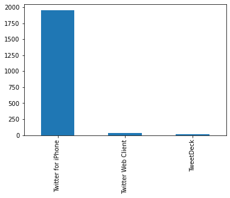

```python
# bar chart showing distribution of device_type.

df['device_type'].value_counts().plot(kind='bar');
```

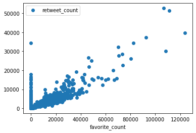

```python
# a scatter plot showing correlation between retweet_count and favorite_count.

df.plot(x='favorite_count', y='retweet_count', style='o');
```

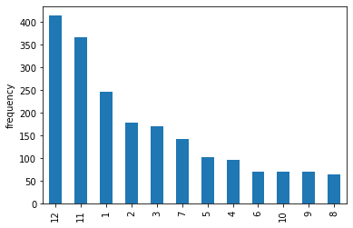

```python
# barchart showing the month distribution of how people tweeted.

fig,ax = plt.subplots()
df.month.value_counts().plot(ax = ax, kind = 'bar', ylabel = 'frequency')
plt.show()
```